# Reproducible Science & Figures Assignment

2023-12-04

## QUESTION 01: Data Visualisation for Science Communication

*Create a figure using the Palmer Penguin dataset that is correct but badly communicates the data. **Do not make a boxplot**.*

*Use the following references to guide you:*

- [*https://www.nature.com/articles/533452a*](https://www.nature.com/articles/533452a)
- [*https://elifesciences.org/articles/16800*](https://elifesciences.org/articles/16800)

*Note: Focus on visual elements rather than writing misleading text on it.*

### a) Provide your figure here:

Setup code to install + library the necessary packages and check that the penguins dataset has properly loaded in

[output not shown]

[output not shown]

```
##       species          island    bill_length_mm  bill_depth_mm
##  Adelie   :152   Biscoe   :168   Min.   :32.10   Min.   :13.10
##  Chinstrap: 68   Dream    :124   1st Qu.:39.23   1st Qu.:15.60
##  Gentoo   :124   Torgersen: 52   Median :44.45   Median :17.30
##                                  Mean   :43.92   Mean   :17.15
##                                  3rd Qu.:48.50   3rd Qu.:18.70
##                                  Max.   :59.60   Max.   :21.50
##                                  NA's   :2       NA's   :2
##  flipper_length_mm  body_mass_g       sex           year
##  Min.   :172.0     Min.   :2700   female:165   Min.   :2007
##  1st Qu.:190.0     1st Qu.:3550   male  :168   1st Qu.:2007
##  Median :197.0     Median :4050   NA's  : 11   Median :2008
##  Mean   :200.9     Mean   :4202                Mean   :2008
##  3rd Qu.:213.0     3rd Qu.:4750                3rd Qu.:2009
##  Max.   :231.0     Max.   :6300                Max.   :2009
##  NA's   :2         NA's   :2
```

Code chunk for creating the plot

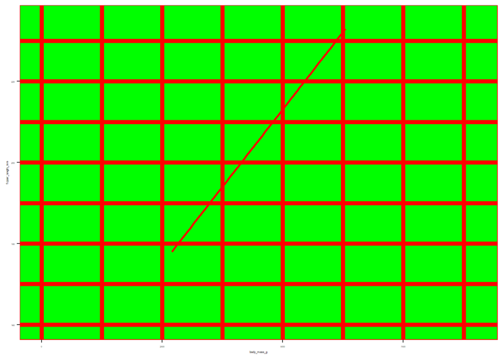

### b) Write about how your design choices mislead the reader about the underlying data (200-300 words).

Firstly, the figure does not show all of the original data points. This prevents the reader seeing the true variation in the data and thus inhibits their understanding of how strong the displayed relationship between body mass and flipper length is. This also prevents potentially important sub-groups within the data (such as different penguin species) being viewed in comparison to each other, thus making the relationship appear more generally applicable across penguins than it actually is. The line used has no confidence interval displayed, further obscuring the strength of the relationship.

The scale does not show the entire y-axis (starting at 160 mm rather than 0) – making the relationship appear steeper and thus exaggerating the importance of the relationship in explaining variation in flipper length. The scale shows too much of the x-axis (with values outside of the original data shown) – which also makes the relationship appear steeper, as well as implying that it could be extrapolated from for values outside the original range.

The font size used for the figure text is small and difficult to read. This could lead to readers misunderstanding what variables are displayed. No title is provided, which may exacerbate this issue. The line displaying the relationship between variables is red – the same colour as the grid-lines in the figure background. This makes it hard to distinguish them and thus harder to view the relationship displayed. The figure background uses green, which may create difficulty for readers with colour blindness (or other similar visual impairments) in distinguishing between the line from the background. The gridlines are very thick, and the background colours overly bright (for those without visual impairments) which make the figure difficult to view, thus reducing the time readers spend scrutinising it – making them less likely to notice other misleading elements.

References: Whitlock, Michael, and Dolph Schluter. The Analysis of Biological Data. Third edition. New York: Macmillan International Higher Education, 2020.

## QUESTION 2: Data Pipeline

*Write a data analysis pipeline in your .rmd RMarkdown file. You should be aiming to write a clear explanation of the steps as well as clear code.*

*Your code should include the steps practiced in the lab session:*

### Introduction

The Palmer Penguins dataset provides data collected from over 300 penguins, with each individual measured for several traits - including its body mass, flipper length, and species. For this analysis pipeline, we are interested in whether body mass is a significant predictor of flipper length, whether there is a significant difference in flipper lengths between species, and whether there is a significant interaction between the effects of body mass and species on flipper length.

#### Set up packages

We first need to make sure we have installed and loaded the packages we will need for handling, analysing, and visualising the data. The code below does this.

```r
#Install palmer penguins dataset
install.packages("palmerpenguins")
```

```r
#Install ggplot2 to produce the figure with
install.packages("ggplot2")
#Install janitor to help with cleaning the data
install.packages("janitor")
#Install dplyr to help pipe functions together
install.packages("dplyr")
#Install ragg to help save figures
install.packages("ragg")
#Load the packages into the library
library(palmerpenguins)
library(ggplot2)
library(janitor)
library(dplyr)
library(ragg)
```

#### Load in the data

The following code will look at the raw dataset from the palmerpenguins package and save a copy within our project folder for us to work on.

```r
#Check that we have properly loaded in the penguin data
head(penguins_raw)
```

```
## # A tibble: 6 × 17
##   studyName `Sample Number` Species          Region Island Stage `Individual ID`
##   <chr>               <dbl> <chr>            <chr>  <chr>  <chr> <chr>
## 1 PAL0708                 1 Adelie Penguin … Anvers Torge… Adul… N1A1
## 2 PAL0708                 2 Adelie Penguin … Anvers Torge… Adul… N1A2
## 3 PAL0708                 3 Adelie Penguin … Anvers Torge… Adul… N2A1
## 4 PAL0708                 4 Adelie Penguin … Anvers Torge… Adul… N2A2
## 5 PAL0708                 5 Adelie Penguin … Anvers Torge… Adul… N3A1
## 6 PAL0708                 6 Adelie Penguin … Anvers Torge… Adul… N3A2
## # ℹ 10 more variables: `Clutch Completion` <chr>, `Date Egg` <date>,
## #   `Culmen Length (mm)` <dbl>, `Culmen Depth (mm)` <dbl>,
## #   `Flipper Length (mm)` <dbl>, `Body Mass (g)` <dbl>, Sex <chr>,
## #   `Delta 15 N (o/oo)` <dbl>, `Delta 13 C (o/oo)` <dbl>, Comments <chr>
```

```r
#Give ourselves an overview of the raw data
summary(penguins_raw)
```

```
##   studyName         Sample Number      Species             Region
##  Length:344         Min.   :  1.00   Length:344         Length:344
##  Class :character   1st Qu.: 29.00   Class :character   Class :character
##  Mode  :character   Median : 58.00   Mode  :character   Mode  :character
##                     Mean   : 63.15
##                     3rd Qu.: 95.25
##                     Max.   :152.00
##
##     Island             Stage           Individual ID      Clutch Completion
##  Length:344         Length:344         Length:344         Length:344
##  Class :character   Class :character   Class :character   Class :character
##  Mode  :character   Mode  :character   Mode  :character   Mode  :character
##
##
##
##
##     Date Egg          Culmen Length (mm) Culmen Depth (mm) Flipper Length (mm)
##  Min.   :2007-11-09   Min.   :32.10      Min.   :13.10     Min.   :172.0
##  1st Qu.:2007-11-28   1st Qu.:39.23      1st Qu.:15.60     1st Qu.:190.0
##  Median :2008-11-09   Median :44.45      Median :17.30     Median :197.0
##  Mean   :2008-11-27   Mean   :43.92      Mean   :17.15     Mean   :200.9
##  3rd Qu.:2009-11-16   3rd Qu.:48.50      3rd Qu.:18.70     3rd Qu.:213.0
##  Max.   :2009-12-01   Max.   :59.60      Max.   :21.50     Max.   :231.0
##                       NA's   :2          NA's   :2         NA's   :2
##  Body Mass (g)      Sex            Delta 15 N (o/oo) Delta 13 C (o/oo)
##  Min.   :2700   Length:344         Min.   : 7.632    Min.   :-27.02
##  1st Qu.:3550   Class :character   1st Qu.: 8.300    1st Qu.:-26.32
##  Median :4050   Mode  :character   Median : 8.652    Median :-25.83
##  Mean   :4202                      Mean   : 8.733    Mean   :-25.69
##  3rd Qu.:4750                      3rd Qu.: 9.172    3rd Qu.:-25.06
##  Max.   :6300                      Max.   :10.025    Max.   :-23.79
##  NA's   :2                         NA's   :14        NA's   :13
##    Comments
##  Length:344
##  Class :character
##  Mode  :character
##
##
##
##
```

```r
#Save a version of the raw data to work on in a folder within the project
write.csv(penguins_raw, "data/penguins_raw.csv")
```

#### Clean the data

First, this code chunk creates several functions to use for cleaning. We can easily re-use these functions later on if we need to do more cleaning in future. Using the same functions also aids reproducibility by ensuring that future cleaning will be done in the exact same way.

```r
#This function makes the data's column names machine-readable
clean_column_names <- function(raw_penguins) {
    raw_penguins %>%
        clean_names()
}

#This function is to shorten the species names
shorten_species <- function(raw_penguins) {
    raw_penguins %>%
        mutate(species = case_when(
            species == "Adelie Penguin (Pygoscelis adeliae)" ~ "Adelie",
            species == "Chinstrap penguin (Pygoscelis antarctica)" ~ "Chinstrap",
            species == "Gentoo penguin (Pygoscelis papua)" ~ "Gentoo"
        ))
}

#This function removes any empty columns or rows
remove_empty_columns_rows <- function(raw_penguins) {
    raw_penguins %>%
        remove_empty(c("rows", "cols"))
}

# A function to remove rows which contain NA values
remove_NA <- function(penguins_data) {
    penguins_data %>%
        na.omit()
}

#This function subsets the data based on the list of column names
subset_columns <- function(raw_penguins, column_names) {
    raw_penguins %>%
        select(all_of(column_names))
}

#This function subsets the penguins data set based on species
filter_by_species <- function(raw_penguins, selected_species) {
    raw_penguins %>%
        filter(species == selected_species)
}

#This function subsets the penguins data set based on island
filter_by_island <- function(raw_penguins, selected_island) {
  raw_penguins %>%
    filter(island == selected_island)
}
```

Now we will use several of these functions together to clean the data.

```r
#Pipe together all the functions we need to create a clean dataframe
penguins_clean <- penguins_raw %>%
  clean_column_names() %>%
  shorten_species() %>%
  remove_empty_columns_rows()
#Save the clean dataframe
write.csv(penguins_clean, "data/penguins_clean.csv")
#View our clean dataframe to check that the functions have cleaned it properly
head(penguins_clean)
```

```
## # A tibble: 6 × 17
##   study_name sample_number species region island    stage          individual_id
##   <chr>              <dbl> <chr>   <chr>  <chr>     <chr>          <chr>
## 1 PAL0708                1 Adelie  Anvers Torgersen Adult, 1 Egg … N1A1
## 2 PAL0708                2 Adelie  Anvers Torgersen Adult, 1 Egg … N1A2
## 3 PAL0708                3 Adelie  Anvers Torgersen Adult, 1 Egg … N2A1
## 4 PAL0708                4 Adelie  Anvers Torgersen Adult, 1 Egg … N2A2
## 5 PAL0708                5 Adelie  Anvers Torgersen Adult, 1 Egg … N3A1
## 6 PAL0708                6 Adelie  Anvers Torgersen Adult, 1 Egg … N3A2
## # ℹ 10 more variables: clutch_completion <chr>, date_egg <date>,
## #   culmen_length_mm <dbl>, culmen_depth_mm <dbl>, flipper_length_mm <dbl>,
## #   body_mass_g <dbl>, sex <chr>, delta_15_n_o_oo <dbl>, delta_13_c_o_oo <dbl>,
## #   comments <chr>
```

#### Creating an exploratory figure

To visually check whether there appear to be any trends in the relationship between body mass, species, and flipper length, we will make a simple exploratory scatterplot to show the distribution of the data. This code creates a function to produce a scatterplot of body mass against flipper length with different species shown , and then calls it to produce the figure. Using a function to produce the figure means that if we wanted to produce more later on, there would be consistency between figures - which enhances reproducibility and makes it harder to adjust figures to present data in a misleading way.

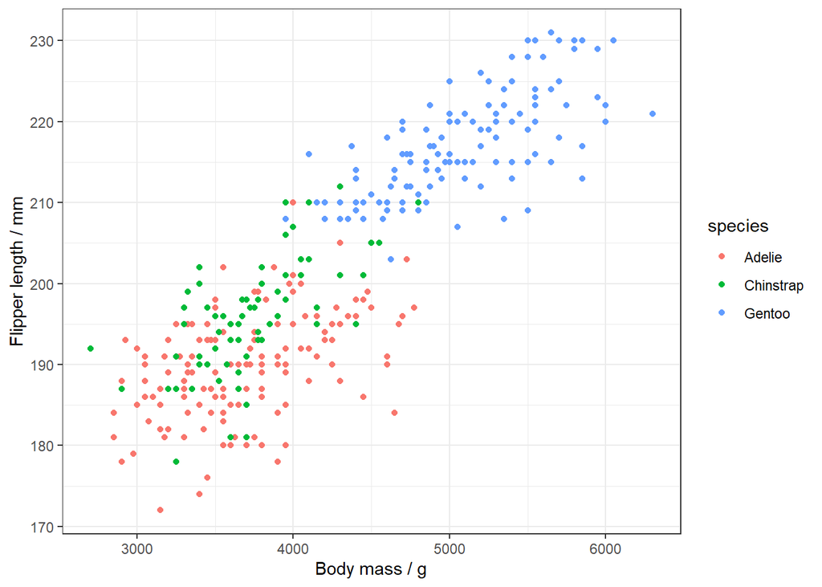

```r
#This function will produce a scatterplot with body mass on the x-axis, flipper length on the y-axis, points coloured by species, and human-readable labels
exploreplot_mass_flipper_species <- function(clean_penguins) {
    ggplot(clean_penguins, aes(x = body_mass_g, y = flipper_length_mm, colour = species)) +
    geom_point() +
    theme_bw() +
    labs(x = "Body mass / g", y = "Flipper length / mm")
}
#Call the function to produce the plot
exploreplot_mass_flipper_species(penguins_clean)
```

#### Save the figure

So that we can use this figure effectively outside of this document with appropriate resolution, size, and scaling, we will save a .png of it in a folder for figures found within this project folder.

```r
#Make the plot an object
exploratory_mass_flipper_species <- exploreplot_mass_flipper_species(penguins_clean)
#Save a png of the figure with appropriate size, resolution, and scaling into the figures folder
agg_png("figures/exploratory_figure_bodymass_flipperlength_species.png",
        width = 1000, height = 500, units = "px",res=300, scaling = 0.4)
exploratory_mass_flipper_species
dev.off()
```

### Hypotheses

We can see from the exploratory figure that there seems to be an association between body mass and flipper length, and that this seems to be affected by species. To test whether body mass is a significant predictor of flipper length, whether there is a significant difference in flipper lengths between species, and whether there is a significant interaction between the effects of body mass and species on flipper length, we will use an analysis of covariance (ANCOVA) test.

Our null hypotheses are: - The mean flipper lengths of each species are not significantly different from each other. - The slope of body mass against flipper length is not significantly different from 0. - The effect of body mass on flipper length does not depend on species (and the effect of species does not depend on body mass), the slopes of each species are not significantly different from each other.

Our alternative hypotheses are: - The mean flipper length of at least one species differs from another species’ mean. - The slope of body mass against flipper length is significantly different from 0. - The effect of body mass on flipper length depends on species (and the effect of species depends on body mass), the slopes of each species are significantly different from each other.

### Run the ANCOVA test

As ANCOVA tests are a type of general linear model, we first need to create a linear model with body mass and species as explanatory variables with interactive effects, and flipper length as a response variable. The code below does this.

```r
#Create the interaction model as specified above using the cleaned data
mass_species_flipper_mod <- lm(flipper_length_mm ~ body_mass_g*species, penguins_clean)
```

#### Check assumptions

Before running our statistical test we must check that the data meets the assumptions the test makes. An ANCOVA test assumes: - Random sampling at all possible combinations of values of explanatory variables - Normally distributed data at all possible combinations of values of explanatory variables - Equal variance across all possible combinations of values of explanatory variables

We can check for normality and equal variance using a qqplot and a residuals vs fitted plot, respectively. Code for a qqplot:

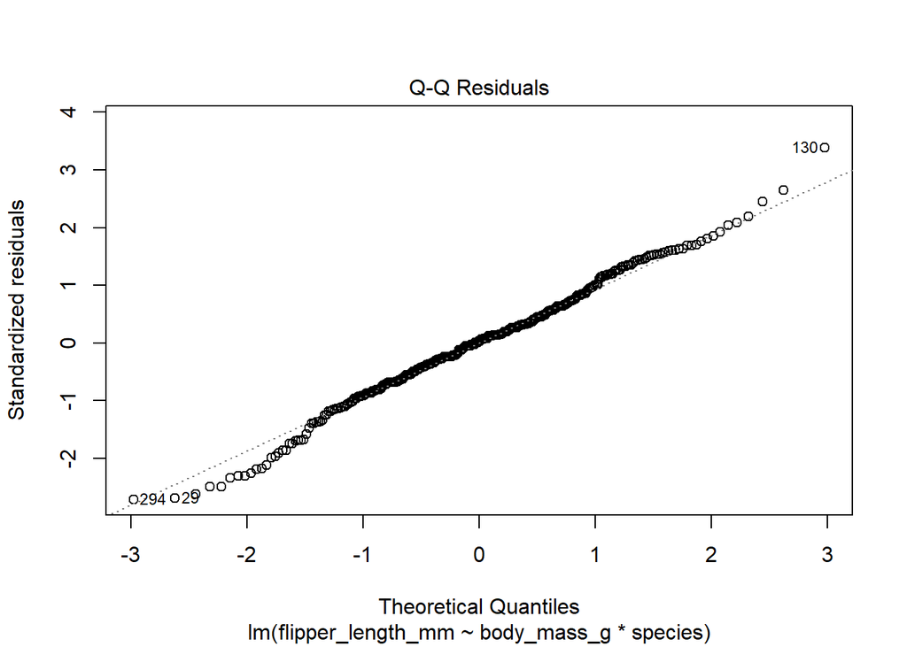

```r
#Produce the plot using the model created earlier
plot(mass_species_flipper_mod, which = 2)
```

The points are very close to the line, indicating that the assumption of normality is met.

Code for a residuals vs fitted plot:

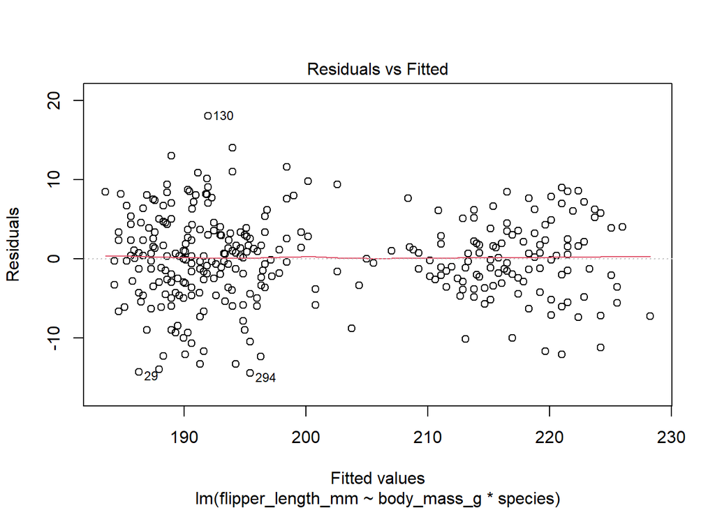

```r
#Produce the plot using the model created earlier
plot(mass_species_flipper_mod, which = 1)
```

The line is very close to straight, with similar amounts of points above and below it, indicating the assumption of equal variance is met. We therefore can safely use an ANCOVA test to test our hypotheses.

### Results and discussion

The following code perfoms an ANCOVA test on our model.

```r
#Summarise the model
summary(mass_species_flipper_mod)
```

```
##
## Call:
## lm(formula = flipper_length_mm ~ body_mass_g * species, data = penguins_clean)
##
## Residuals:
##      Min       1Q   Median       3Q      Max
## -14.4296  -3.3494   0.1719   3.3428  18.0477
##
## Coefficients:
##                                Estimate Std. Error t value Pr(>|t|)
## (Intercept)                   1.652e+02  3.551e+00  46.536  < 2e-16 ***
## body_mass_g                   6.677e-03  9.523e-04   7.011  1.3e-11 ***
## speciesChinstrap             -1.386e+01  7.301e+00  -1.899  0.05844 .
## speciesGentoo                 6.059e+00  6.051e+00   1.001  0.31735
## body_mass_g:speciesChinstrap  5.228e-03  1.949e-03   2.683  0.00766 **
## body_mass_g:speciesGentoo     2.362e-03  1.353e-03   1.746  0.08164 .
## ---
## Signif. codes:  0 '***' 0.001 '**' 0.01 '*' 0.05 '.' 0.1 ' ' 1
##
## Residual standard error: 5.348 on 336 degrees of freedom
##   (2 observations deleted due to missingness)
## Multiple R-squared:  0.8575, Adjusted R-squared:  0.8553
## F-statistic: 404.2 on 5 and 336 DF,  p-value: < 2.2e-16
```

```r
#Run the ANCOVA test on the model
anova(mass_species_flipper_mod)
```

```
## Analysis of Variance Table
##
## Response: flipper_length_mm
##                      Df Sum Sq Mean Sq   F value Pr(>F)
## body_mass_g           1  51176   51176 1789.0875 <2e-16 ***
## species               2   6411    3206  112.0661 <2e-16 ***
## body_mass_g:species   2    228     114    3.9837 0.0195 *
## Residuals           336   9611      29
## ---
## Signif. codes:  0 '***' 0.001 '**' 0.01 '*' 0.05 '.' 0.1 ' ' 1
```

We can see from the R-squared value in the summary section that the model explains 85.53% of the variation observed in flipper length.

The p-values for the F-ratio values can be seen in the “Analysis of Variance Table” section. The p-values are significant to the highest level for both body mass and species individually. The interaction effect of both variables is also significant at the 95% level (p value = 0.0195).

Consequently, we can reject the null hypothesis that the effect of body mass on flipper length does not depend on species (and the effect of species does not depend on body mass), as the slope of at least one species is different to another.

#### Results Figure

To visualise this significant interaction effect, we will plot a figure of body mass against flipper length showing the different slopes of each species with 95% confidence intervals as given by the model. As before, the code to produce the model is given in a function to aid reproducibility.

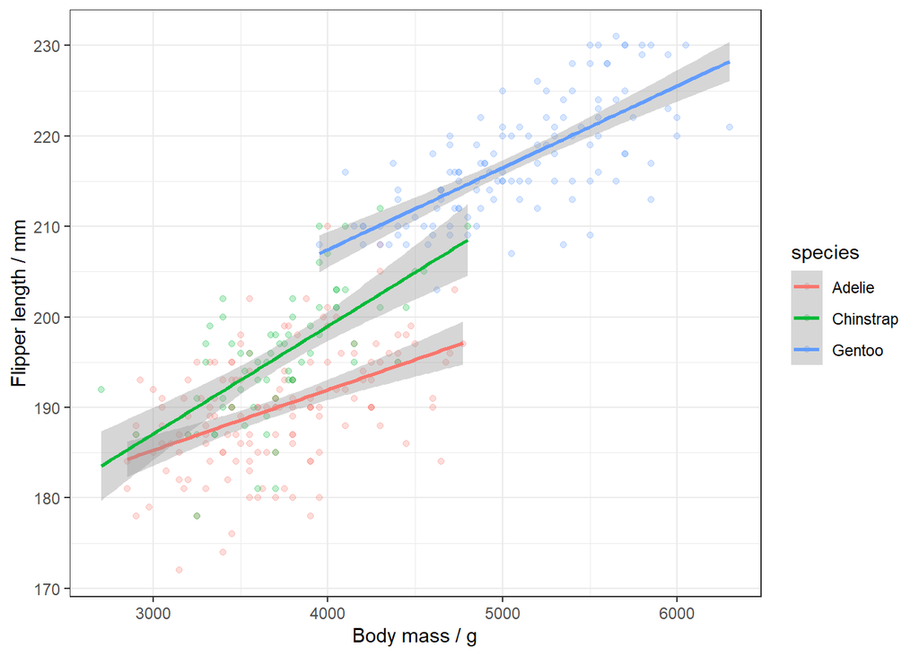

```r
#This function will produce a scatterplot with body mass on the x-axis, flipper length on the y-axis, points coloured by species and slightly transparent, separate linear slopes (with confidence intervals shown) for each species, and human-readable labels.
plot_mass_flipper_species <- function(clean_penguins) {
    ggplot(clean_penguins, aes(x = body_mass_g, y = flipper_length_mm, colour = species)) +
    geom_point(alpha = 0.25) +
    geom_smooth(method = "lm") +
    theme_bw() +
    labs(x = "Body mass / g", y = "Flipper length / mm")
}
#Call the function to produce the plot
plot_mass_flipper_species(penguins_clean)
```

#### Save the figure

Similarly to before, this code will save a .png of the results figure for use outside of this document into the “figures” folder”

```r
#Make the plot an object
mass_species_flipper_resultsfig <- plot_mass_flipper_species(penguins_clean)
#Save a png of the figure with appropriate size, resolution, and scaling into the figures folder
agg_png("figures/results_figure_bodymass_flipperlength_species.png",
        width = 1200, height = 500, units = "px",res=500, scaling = 0.3)
mass_species_flipper_resultsfig
dev.off()
```

### Conclusion

The ANCOVA test showed that there is a significant interactive effect of body mass and species on their flipper length. This suggests that the scaling of flipper length with mass is different between species, and thus that penguin flipper physiology depends on more than just penguin size, and that the physiologies of different penguins respond differently to changes in size. The interaction model used for the test explained 85.53% of variation in flipper length. This is very high, indicating that body mass and species are very important drivers of flipper length in the penguins observed.

## QUESTION 3: Open Science

### a) GitHub

*Upload your RProject you created for **Question 2** and any files and subfolders used to GitHub. Do not include any identifiers such as your name. Make sure your GitHub repo is public.*

*You will be marked on your repo organisation and readability.*

### b) Share your repo with a partner, download, and try to run their data pipeline.

*You **must** provide this so I can verify there is no plagiarism between you and your partner.*

### c) Reflect on your experience running their code. (300-500 words)

- *What elements of your partner’s code helped you to understand their data pipeline?*
- *Did it run? Did you need to fix anything?*
- *What suggestions would you make for improving their code to make it more understandable or reproducible, and why?*
- *If you needed to alter your partner’s figure using their code, do you think that would be easy or difficult, and why?*

### d) Reflect on your own code based on your experience with your partner’s code and their review of yours. (300-500 words)

- *What improvements did they suggest, and do you agree?*
- *What did you learn about writing code for other people?*